# Linear Models with R

Non-constant SD can be evidence of a mispecified model or a very skewed response where some values are orders of magnitude larger than the rest of the data. Notice that our response is quite skewed:

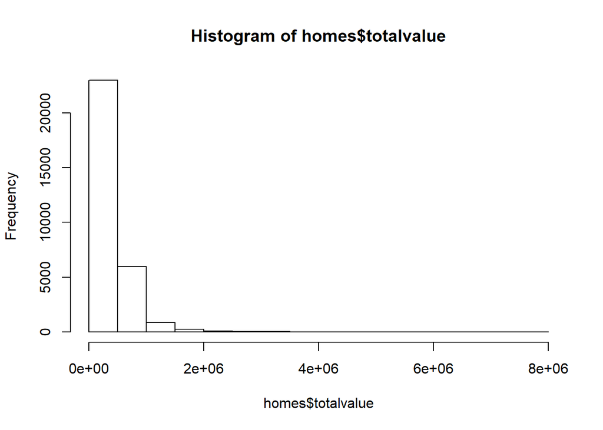

```r
hist(homes$totalvalue)
```

We could try transforming totalvalue to a different scale. A common transformation is a log transformation. This certainly looks more symmetric but definitely has some outlying observations.

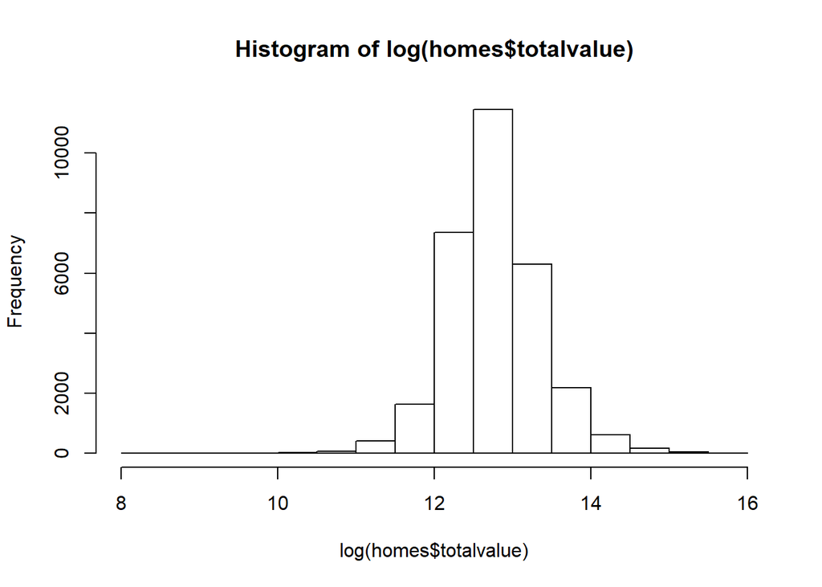

```r
hist(log(homes$totalvalue))
```

Let’s try modeling log-transformed totalvalue and checking our diagnostic plots.

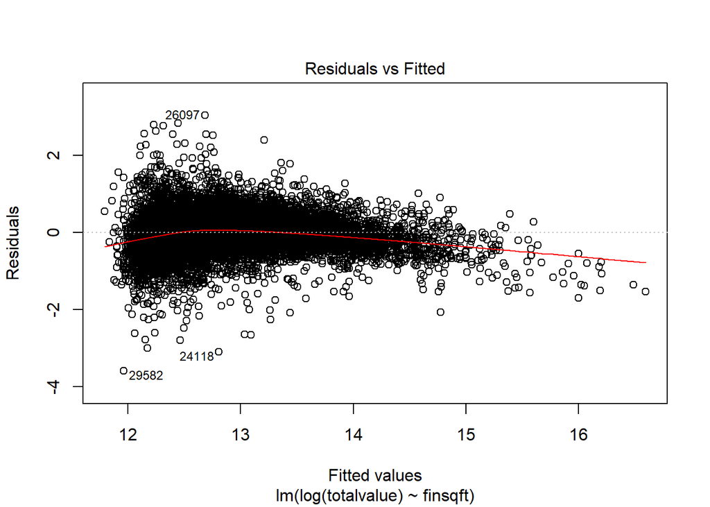

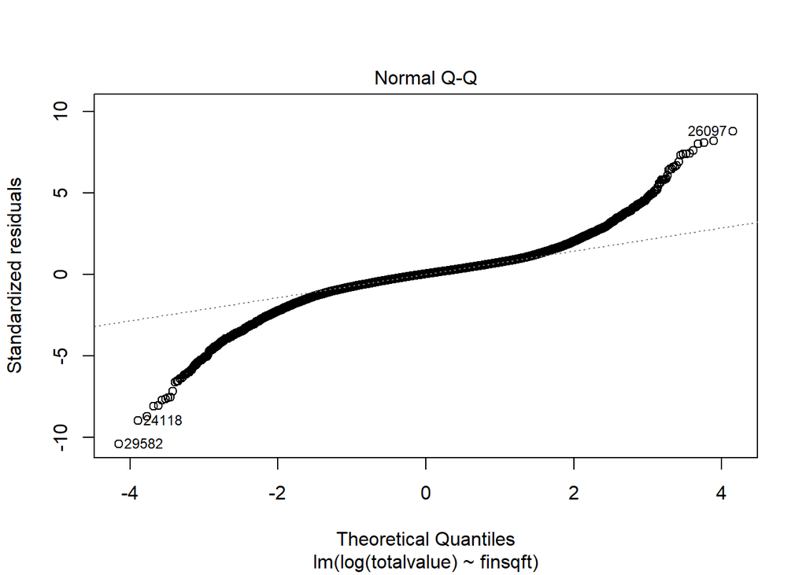

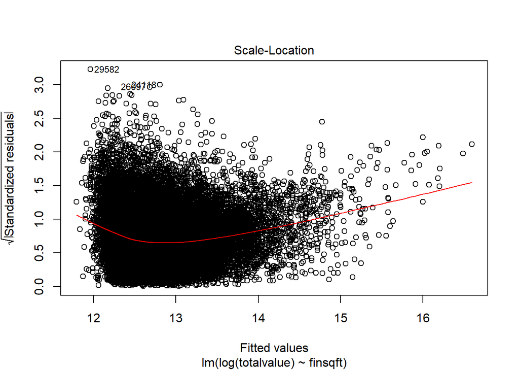

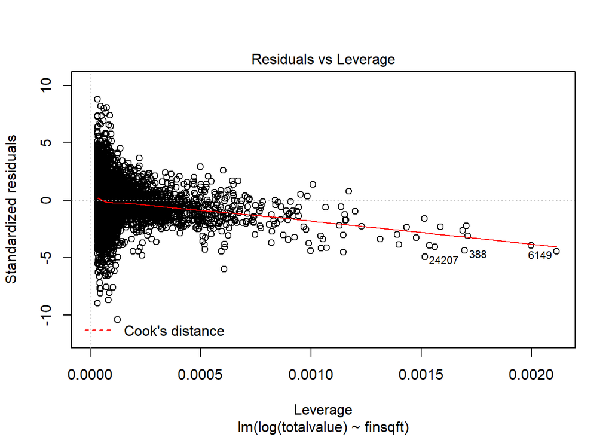

```r
m2 <- lm(log(totalvalue) ~ finsqft, data = homes)
plot(m2)
```

The plots look better but there is still evidence of non-constant variance. We may need to include other predictors in our model.

Let’s also simulate some data from the model and compare to the observed totalvalue:

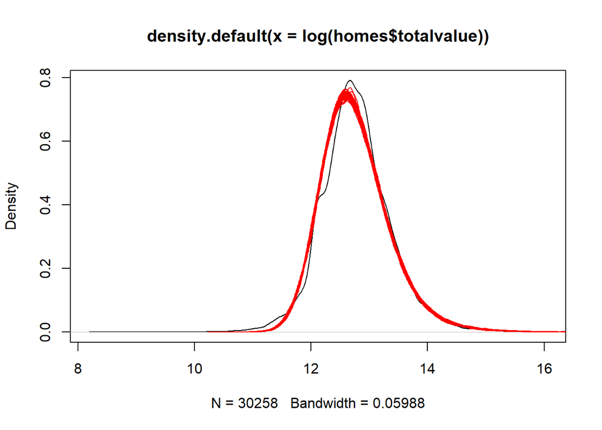

```r
sim_tv <- simulate(m2, nsim = 50)
plot(density(log(homes$totalvalue)))
for(i in 1:50)lines(density(sim_tv[[i]]), col = "red")
```

Not bad.

But first how to interpret what we have at the moment?

```r
coef(m2) %>% round(4)
```

```
## (Intercept)     finsqft
##     11.7213      0.0005
```

The response is log transformed, so interpretation of coefficients changes. We first need to exponentiate and then interpret as multiplicative instead of additive effect.

```r
exp(coef(m2)) %>% round(4)
```

```
## (Intercept)     finsqft
## 123168.2092      1.0005
```

Naive interpretation - each additional finished square foot increases price by 0.05%

We can (and should) look at the confidence interval of the estimates

```r
exp(confint(m2)) %>% round(5)
```

```
##                   2.5 %       97.5 %
## (Intercept) 122029.7943 124317.24430
## finsqft          1.0005      1.00051
```

Let’s examine the summary output in detail:

```r
summary(m2)
```

```
##
## Call:
## lm(formula = log(totalvalue) ~ finsqft, data = homes)
##
## Residuals:
##     Min      1Q  Median      3Q     Max
## -3.5973 -0.1611  0.0130  0.1719  3.0423
##
## Coefficients:
##              Estimate Std. Error t value Pr(>|t|)
## (Intercept) 1.172e+01  4.738e-03  2474.1   <2e-16 ***
## finsqft     5.049e-04  2.077e-06   243.1   <2e-16 ***
## ---
## Signif. codes:  0 '***' 0.001 '**' 0.01 '*' 0.05 '.' 0.1 ' ' 1
##
## Residual standard error: 0.3452 on 30256 degrees of freedom
## Multiple R-squared:  0.6613, Adjusted R-squared:  0.6613
## F-statistic: 5.908e+04 on 1 and 30256 DF,  p-value: < 2.2e-16
```

```
Call:
lm(formula = log(totalvalue) ~ finsqft, data = homes)
```

Repeat of the function call. Useful if result is saved and then printed later.

```
Residuals:
    Min      1Q  Median      3Q     Max
-3.5973 -0.1611  0.0130  0.1719  3.0423
```

Quick check of the distributional (Normal) assumptions of residuals. Median should not be far from 0. Max and Min, and 1Q and 3Q, should be roughly equal in absolute value.

```
Coefficients:
             Estimate Std. Error t value Pr(>|t|)
(Intercept) 1.172e+01  4.738e-03  2474.1   <2e-16 ***
finsqft     5.049e-04  2.077e-06   243.1   <2e-16 ***
---
Signif. codes:  0 ‘***’ 0.001 ‘**’ 0.01 ‘*’ 0.05 ‘.’ 0.1 ‘ ’ 1
```

- **Estimate**: the weight/slope/coefficient estimate
- **Std. Error**: standard error of the weight/slope/coefficient estimate
- **t value**: t = Estimate / Std. Error
- **Pr(>|t|)**: Probability of seeing a |t-value| that large if estimate was really 0
- **Signif. codes**: indicators of significance; one star means 0.01 < p < 0.05

```
Residual standard error: 0.3452 on 30256 degrees of freedom
Multiple R-squared:  0.6613,    Adjusted R-squared:  0.6613
F-statistic: 5.908e+04 on 1 and 30256 DF,  p-value: < 2.2e-16
```

- **Residual standard error**: estimate of SD of the Normal dist’n from which the noise is assumed to be drawn
- **degrees of freedom**: # of obs - # of estimates
- **Multiple R-squared**: measure of model fit (0,1)
- **Adjusted R-squared**: measure of model fit adjusted for number of parameters (0,1)
- **F-statistic**: statistic for hypothesis test all coefficients (other than intercept) = 0
- **p-value**: p-value of hypothesis test

## YOUR TURN #2

- Update model `m2` to include the lotsize variable, which is the size of the lot in acres on which the house is built. Call the model `m3`.
- What is the interpretation of lotsize?
- Generate diagnostic plots. What does the last plot (Residuals vs Leverage) reveal?
- OPTIONAL: simulate data from the model (using `simulate`) and compare to the observed totalvalue. TIP: copy and paste the code used previously and update it to use `m3`

```r
# update model m2 to include lotsize; save as m3
m3 <- lm()

# Interptation of lotsize coefficient:


# check diagnostics


# What do you notice about the last plot?


# OPTIONAL: simulate data and compare to observed data
```

## Categorical predictors [Video, Part 4]

Let’s include censustract in our model. This is a categorical variable.

Categorical predictors are added to models in the form of a *contrast*, which is a matrix of zeroes and ones. A contrast can take many forms, but the default contrast in R is the *treatment contrast*. One level of a categorical variable is designated as the baseline or reference level and all other levels are estimated in contrast to the reference level. Therefore if a categorical variable has k levels, the model will have k - 1 coefficients.

```r
summary(homes$censustract)
```

```
##    101 102.01 102.02    103 104.01 104.02    105 106.01 106.02    107    108
##   1768   1925   1188   2751   1506   1391   1406   1359   1453   1205   1055
## 109.02    110    111 112.01 112.02 113.01 113.02 113.03    114
##     57   2380   3375   1385   1437   1737    293   1055   1532
```

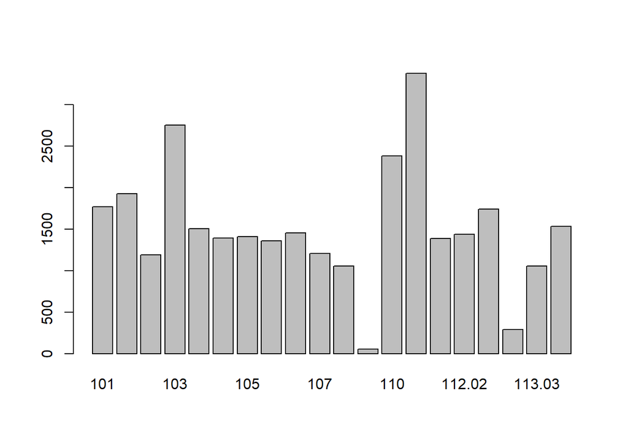

```r
plot(homes$censustract)
```

```r
m4 <- lm(log(totalvalue) ~ finsqft + lotsize + censustract, data = homes)
summary(m4)
```

```
##
## Call:
## lm(formula = log(totalvalue) ~ finsqft + lotsize + censustract,
##     data = homes)
##
## Residuals:
##     Min      1Q  Median      3Q     Max
## -4.1120 -0.1402  0.0097  0.1596  3.1575
##
## Coefficients:
##                     Estimate Std. Error  t value Pr(>|t|)
## (Intercept)        1.183e+01  8.420e-03 1405.208  < 2e-16 ***
## finsqft            4.523e-04  1.987e-06  227.605  < 2e-16 ***
## lotsize            4.516e-03  8.368e-05   53.962  < 2e-16 ***
## censustract102.01 -8.985e-02  1.007e-02   -8.921  < 2e-16 ***
## censustract102.02  1.028e-01  1.149e-02    8.948  < 2e-16 ***
## censustract103     3.093e-03  9.359e-03    0.330  0.74103
## censustract104.01 -1.358e-01  1.067e-02  -12.735  < 2e-16 ***
## censustract104.02  4.974e-03  1.101e-02    0.452  0.65146
## censustract105     5.151e-02  1.093e-02    4.711 2.48e-06 ***
## censustract106.01  5.104e-02  1.104e-02    4.622 3.82e-06 ***
## censustract106.02  9.557e-03  1.085e-02    0.881  0.37853
## censustract107    -1.939e-01  1.151e-02  -16.855  < 2e-16 ***
## censustract108     2.153e-02  1.189e-02    1.811  0.07022 .
## censustract109.02  2.441e-01  4.095e-02    5.962 2.52e-09 ***
## censustract110     2.802e-01  9.688e-03   28.927  < 2e-16 ***
## censustract111    -4.839e-03  9.008e-03   -0.537  0.59115
## censustract112.01 -9.269e-02  1.092e-02   -8.485  < 2e-16 ***
## censustract112.02 -2.687e-03  1.085e-02   -0.248  0.80442
## censustract113.01 -1.260e-01  1.032e-02  -12.209  < 2e-16 ***
## censustract113.02 -5.746e-02  1.927e-02   -2.983  0.00286 **
## censustract113.03  2.548e-02  1.193e-02    2.137  0.03264 *
## censustract114    -4.910e-01  1.067e-02  -46.022  < 2e-16 ***
## ---
## Signif. codes:  0 '***' 0.001 '**' 0.01 '*' 0.05 '.' 0.1 ' ' 1
##
## Residual standard error: 0.3041 on 30236 degrees of freedom
## Multiple R-squared:  0.7373, Adjusted R-squared:  0.7371
## F-statistic:  4040 on 21 and 30236 DF,  p-value: < 2.2e-16
```

Every censustract coefficient is in comparison to censustract 101. It got designated as the reference level since it came first numerically.

As a whole does censustract contribute to the model? We can’t (or shouldn’t) tell just by looking at all the p-values. The formal method for evaluating if a variable contributes to a model is the *partial F test*. We can easily run that in R with the `anova()` function.

```r
anova(m4)
```

```
## Analysis of Variance Table
##
## Response: log(totalvalue)
##                Df Sum Sq Mean Sq  F value    Pr(>F)
## finsqft         1 7039.4  7039.4 76105.35 < 2.2e-16 ***
## lotsize         1  174.5   174.5  1886.41 < 2.2e-16 ***
## censustract    19  633.8    33.4   360.65 < 2.2e-16 ***
## Residuals   30236 2796.7     0.1
## ---
## Signif. codes:  0 '***' 0.001 '**' 0.01 '*' 0.05 '.' 0.1 ' ' 1
```

This says that with finsqft and lotsize already in the model, censustract appears to help explain or account for the remaining variability.

Another equivalent way is to use anova to compare the new model with censustract to the previous model (m3) without censustract

```r
m3 <- lm(log(totalvalue) ~ finsqft + lotsize, data = homes)
anova(m3, m4)
```

```
## Analysis of Variance Table
##
## Model 1: log(totalvalue) ~ finsqft + lotsize
## Model 2: log(totalvalue) ~ finsqft + lotsize + censustract
##   Res.Df    RSS Df Sum of Sq      F    Pr(>F)
## 1  30255 3430.5
## 2  30236 2796.7 19    633.81 360.65 < 2.2e-16 ***
## ---
## Signif. codes:  0 '***' 0.001 '**' 0.01 '*' 0.05 '.' 0.1 ' ' 1
```

Notice the F statistic is the same.

How do the diagnostic plots and simulated data look?

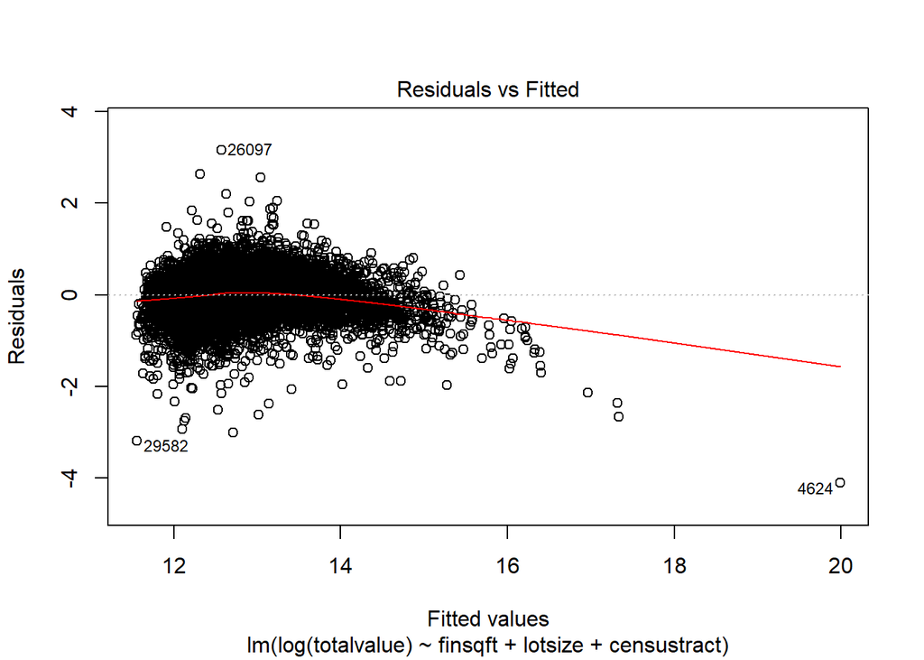

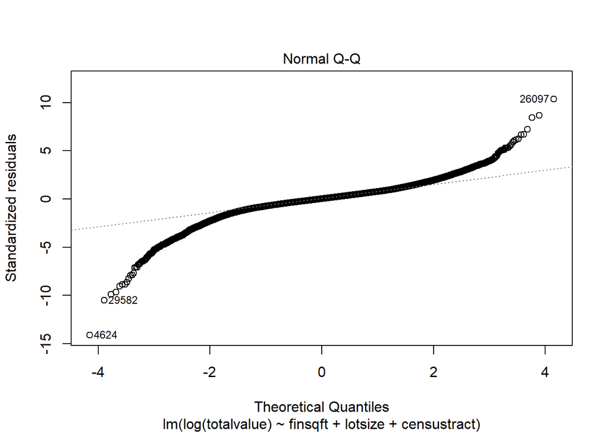

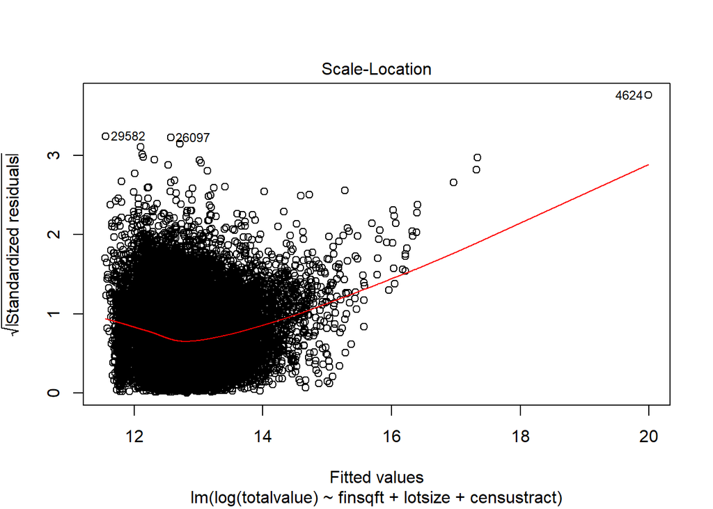

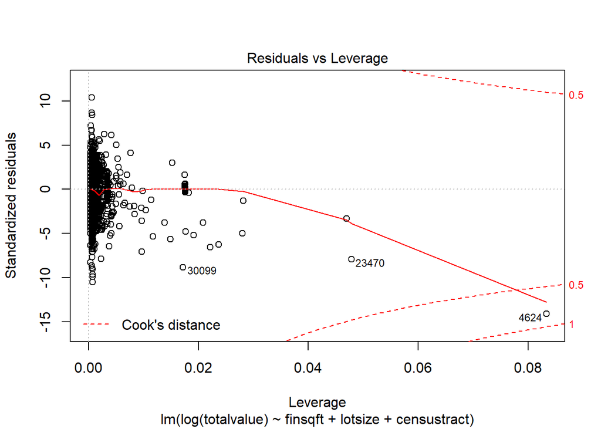

```r
plot(m4)
```

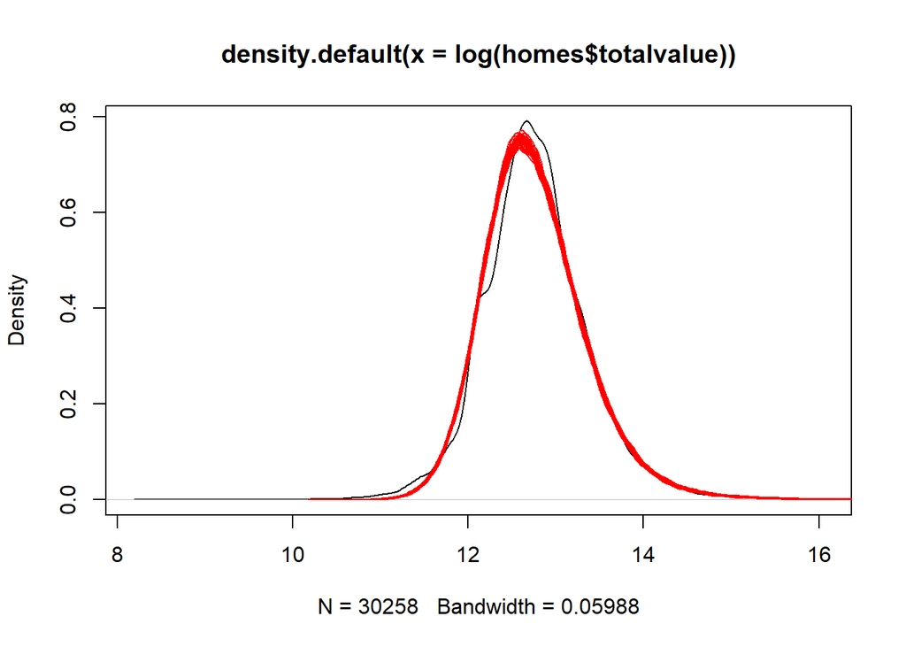

```r
sim_tv <- simulate(m4, nsim = 50)
plot(density(log(homes$totalvalue)))
for(i in 1:50)lines(density(sim_tv[[i]]), col = "red")
```

How to interpret?

```r
exp(coef(m4)) %>% round(4)
```

```
##       (Intercept)           finsqft           lotsize censustract102.01
##       137632.3236            1.0005            1.0045            0.9141
## censustract102.02    censustract103 censustract104.01 censustract104.02
##            1.1082            1.0031            0.8730            1.0050
##    censustract105 censustract106.01 censustract106.02    censustract107
##            1.0529            1.0524            1.0096            0.8237
##    censustract108 censustract109.02    censustract110    censustract111
##            1.0218            1.2765            1.3234            0.9952
## censustract112.01 censustract112.02 censustract113.01 censustract113.02
##            0.9115            0.9973            0.8816            0.9442
## censustract113.03    censustract114
##            1.0258            0.6120
```

The censustract coefficients are in contrast to censustract 101. Therefore…

- we expect the totalvalue of a home in tract 102.01 to be about 9% (0.91 - 1 = -0.09) less than a home in tract 101.
- we expect the totalvalue of a home in tract 109.02 to be about 28% (1.28 - 1 = 0.28) more than a home in tract 101.
- and so on

Are these differences significant? Check the model summary:

```r
summary(m4)
```

```
##
## Call:
## lm(formula = log(totalvalue) ~ finsqft + lotsize + censustract,
##     data = homes)
##
## Residuals:
##     Min      1Q  Median      3Q     Max
## -4.1120 -0.1402  0.0097  0.1596  3.1575
##
## Coefficients:
##                     Estimate Std. Error  t value Pr(>|t|)
## (Intercept)        1.183e+01  8.420e-03 1405.208  < 2e-16 ***
## finsqft            4.523e-04  1.987e-06  227.605  < 2e-16 ***
## lotsize            4.516e-03  8.368e-05   53.962  < 2e-16 ***
## censustract102.01 -8.985e-02  1.007e-02   -8.921  < 2e-16 ***
## censustract102.02  1.028e-01  1.149e-02    8.948  < 2e-16 ***
## censustract103     3.093e-03  9.359e-03    0.330  0.74103
## censustract104.01 -1.358e-01  1.067e-02  -12.735  < 2e-16 ***
## censustract104.02  4.974e-03  1.101e-02    0.452  0.65146
## censustract105     5.151e-02  1.093e-02    4.711 2.48e-06 ***
## censustract106.01  5.104e-02  1.104e-02    4.622 3.82e-06 ***
## censustract106.02  9.557e-03  1.085e-02    0.881  0.37853
## censustract107    -1.939e-01  1.151e-02  -16.855  < 2e-16 ***
## censustract108     2.153e-02  1.189e-02    1.811  0.07022 .
## censustract109.02  2.441e-01  4.095e-02    5.962 2.52e-09 ***
## censustract110     2.802e-01  9.688e-03   28.927  < 2e-16 ***
## censustract111    -4.839e-03  9.008e-03   -0.537  0.59115
## censustract112.01 -9.269e-02  1.092e-02   -8.485  < 2e-16 ***
## censustract112.02 -2.687e-03  1.085e-02   -0.248  0.80442
## censustract113.01 -1.260e-01  1.032e-02  -12.209  < 2e-16 ***
## censustract113.02 -5.746e-02  1.927e-02   -2.983  0.00286 **
## censustract113.03  2.548e-02  1.193e-02    2.137  0.03264 *
## censustract114    -4.910e-01  1.067e-02  -46.022  < 2e-16 ***
## ---
## Signif. codes:  0 '***' 0.001 '**' 0.01 '*' 0.05 '.' 0.1 ' ' 1
##
## Residual standard error: 0.3041 on 30236 degrees of freedom
## Multiple R-squared:  0.7373, Adjusted R-squared:  0.7371
## F-statistic:  4040 on 21 and 30236 DF,  p-value: < 2.2e-16
```

Use the relevel() function to set a new reference level Let’s set the reference level to “109.02”

```r
homes$censustract <- relevel(homes$censustract, ref = "109.02")
m4 <- lm(log(totalvalue) ~ finsqft + lotsize + censustract, data = homes)
summary(m4)
```

```
##
## Call:
## lm(formula = log(totalvalue) ~ finsqft + lotsize + censustract,
##     data = homes)
##
## Residuals:
##     Min      1Q  Median      3Q     Max
## -4.1120 -0.1402  0.0097  0.1596  3.1575
##
## Coefficients:
##                     Estimate Std. Error t value Pr(>|t|)
## (Intercept)        1.208e+01  4.051e-02 298.095  < 2e-16 ***
## finsqft            4.523e-04  1.987e-06 227.605  < 2e-16 ***
## lotsize            4.516e-03  8.368e-05  53.962  < 2e-16 ***
## censustract101    -2.441e-01  4.095e-02  -5.962 2.52e-09 ***
## censustract102.01 -3.340e-01  4.088e-02  -8.169 3.22e-16 ***
## censustract102.02 -1.414e-01  4.125e-02  -3.427 0.000612 ***
## censustract103    -2.410e-01  4.070e-02  -5.922 3.22e-09 ***
## censustract104.01 -3.800e-01  4.105e-02  -9.256  < 2e-16 ***
## censustract104.02 -2.391e-01  4.111e-02  -5.817 6.05e-09 ***
## censustract105    -1.926e-01  4.109e-02  -4.687 2.78e-06 ***
## censustract106.01 -1.931e-01  4.112e-02  -4.695 2.67e-06 ***
## censustract106.02 -2.346e-01  4.107e-02  -5.711 1.13e-08 ***
## censustract107    -4.380e-01  4.125e-02 -10.619  < 2e-16 ***
## censustract108    -2.226e-01  4.136e-02  -5.382 7.42e-08 ***
## censustract110     3.612e-02  4.078e-02   0.886 0.375800
## censustract111    -2.490e-01  4.062e-02  -6.129 8.97e-10 ***
## censustract112.01 -3.368e-01  4.112e-02  -8.191 2.68e-16 ***
## censustract112.02 -2.468e-01  4.108e-02  -6.008 1.90e-09 ***
## censustract113.01 -3.702e-01  4.096e-02  -9.037  < 2e-16 ***
## censustract113.02 -3.016e-01  4.405e-02  -6.846 7.72e-12 ***
## censustract113.03 -2.186e-01  4.137e-02  -5.285 1.27e-07 ***
## censustract114    -7.351e-01  4.106e-02 -17.902  < 2e-16 ***
## ---
## Signif. codes:  0 '***' 0.001 '**' 0.01 '*' 0.05 '.' 0.1 ' ' 1
##
## Residual standard error: 0.3041 on 30236 degrees of freedom
## Multiple R-squared:  0.7373, Adjusted R-squared:  0.7371
## F-statistic:  4040 on 21 and 30236 DF,  p-value: < 2.2e-16
```

```r
anova(m4)
```

```
## Analysis of Variance Table
##
## Response: log(totalvalue)
##                Df Sum Sq Mean Sq  F value    Pr(>F)
## finsqft         1 7039.4  7039.4 76105.35 < 2.2e-16 ***
## lotsize         1  174.5   174.5  1886.41 < 2.2e-16 ***
## censustract    19  633.8    33.4   360.65 < 2.2e-16 ***
## Residuals   30236 2796.7     0.1
## ---
## Signif. codes:  0 '***' 0.001 '**' 0.01 '*' 0.05 '.' 0.1 ' ' 1
```

```r
# reset levels back to previous order with "101" first
homes$censustract <- factor(as.character(homes$censustract))
```

## YOUR TURN #3

- Add the cooling variable to model `m4` and save it as `m5`.
- Does it help our model?
- What is the interpretation of the cooling coefficient?

```r
# Add the cooling variable to model `m4` and save it as `m5`.
m5 <- lm()

# Does it help the model?

# What is the interpretation of the cooling coefficient?
```

## Interactions and Effect Plots [Video, Part 5]

Often it isn’t reasonable to expect the effect of one variable to be the same regardless of other variables. For example, the effect of finsqft may depend on censustract. Or the effect of lotsize may depend on finsqft.

Use the colon to specify interactions on an individual basis.

Example: finsqft:censustract Example: finsqft:lotsize

Does the effect of finsqft depend on censustract? Does the effect of finsqft depend on lotsize?

```r
m6 <- lm(log(totalvalue) ~ finsqft + lotsize + censustract + cooling +
           finsqft:censustract + finsqft:lotsize,
         data = homes)
summary(m6)
```

```
##
## Call:
## lm(formula = log(totalvalue) ~ finsqft + lotsize + censustract +
##     cooling + finsqft:censustract + finsqft:lotsize, data = homes)
##
## Residuals:
##     Min      1Q  Median      3Q     Max
## -3.2210 -0.1409  0.0027  0.1500  3.3844
##
## Coefficients:
##                             Estimate Std. Error t value Pr(>|t|)
## (Intercept)                1.163e+01  1.540e-02 755.166  < 2e-16 ***
## finsqft                    4.436e-04  6.346e-06  69.900  < 2e-16 ***
## lotsize                    8.641e-03  1.355e-04  63.775  < 2e-16 ***
## censustract102.01         -1.180e-01  2.222e-02  -5.309 1.11e-07 ***
## censustract102.02          2.029e-01  2.623e-02   7.735 1.07e-14 ***
## censustract103             4.532e-02  2.428e-02   1.866 0.062045 .
## censustract104.01         -2.104e-01  2.167e-02  -9.705  < 2e-16 ***
## censustract104.02          6.680e-02  2.475e-02   2.699 0.006953 **
## censustract105             7.831e-02  2.724e-02   2.874 0.004052 **
## censustract106.01          2.082e-01  2.896e-02   7.188 6.74e-13 ***
## censustract106.02         -1.657e-01  2.701e-02  -6.136 8.59e-10 ***
## censustract107            -3.593e-02  3.536e-02  -1.016 0.309587
## censustract108            -2.072e-02  2.637e-02  -0.786 0.431923
## censustract109.02          5.477e-01  1.434e-01   3.821 0.000133 ***
## censustract110             3.590e-01  2.124e-02  16.901  < 2e-16 ***
## censustract111            -9.553e-02  2.061e-02  -4.635 3.58e-06 ***
## censustract112.01         -1.959e-01  2.258e-02  -8.677  < 2e-16 ***
## censustract112.02         -3.515e-02  2.337e-02  -1.504 0.132650
## censustract113.01         -1.526e-01  2.231e-02  -6.842 7.95e-12 ***
## censustract113.02          2.682e-02  5.436e-02   0.493 0.621713
## censustract113.03         -1.187e-02  4.043e-02  -0.294 0.769024
## censustract114            -5.333e-01  2.203e-02 -24.207  < 2e-16 ***
## coolingCentral Air         2.742e-01  5.641e-03  48.604  < 2e-16 ***
## finsqft:censustract102.01  9.641e-07  9.997e-06   0.096 0.923172
## finsqft:censustract102.02 -4.952e-05  9.794e-06  -5.057 4.29e-07 ***
## finsqft:censustract103    -4.440e-05  1.130e-05  -3.930 8.50e-05 ***
## finsqft:censustract104.01  4.148e-05  8.953e-06   4.633 3.61e-06 ***
## finsqft:censustract104.02 -3.481e-05  9.180e-06  -3.792 0.000150 ***
## finsqft:censustract105    -2.810e-05  1.137e-05  -2.471 0.013496 *
## finsqft:censustract106.01 -1.029e-04  1.344e-05  -7.657 1.96e-14 ***
## finsqft:censustract106.02  6.919e-05  1.289e-05   5.370 7.94e-08 ***
## finsqft:censustract107    -1.449e-04  2.247e-05  -6.447 1.16e-10 ***
## finsqft:censustract108     1.522e-06  1.168e-05   0.130 0.896275
## finsqft:censustract109.02 -1.584e-04  6.375e-05  -2.485 0.012969 *
## finsqft:censustract110    -3.983e-05  7.989e-06  -4.986 6.20e-07 ***
## finsqft:censustract111     3.277e-05  8.805e-06   3.721 0.000198 ***
## finsqft:censustract112.01  6.592e-05  9.826e-06   6.709 2.00e-11 ***
## finsqft:censustract112.02  7.912e-06  9.101e-06   0.869 0.384621
## finsqft:censustract113.01  1.180e-05  1.080e-05   1.093 0.274458
## finsqft:censustract113.02 -6.905e-05  3.491e-05  -1.978 0.047937 *
## finsqft:censustract113.03 -7.817e-06  2.273e-05  -0.344 0.730884
## finsqft:censustract114     5.104e-05  1.085e-05   4.703 2.57e-06 ***
## finsqft:lotsize           -1.244e-06  3.531e-08 -35.235  < 2e-16 ***
## ---
## Signif. codes:  0 '***' 0.001 '**' 0.01 '*' 0.05 '.' 0.1 ' ' 1
##
## Residual standard error: 0.2851 on 30215 degrees of freedom
## Multiple R-squared:  0.7693, Adjusted R-squared:  0.769
## F-statistic:  2399 on 42 and 30215 DF,  p-value: < 2.2e-16
```

Is the interaction “significant”? In other words, does it make the model better? Does the interaction make the model better at explaining the variability in totalvalue. Again the partial F test can help us assess this.

The car package’s `Anova` function may be preferred in this case. It assesses an interactions contribution with *all other predictors in the model*. The base R `anova` function is sequential. It assesses the contribution of a predictor given that other predictors *before it* are already in the model.

```r
anova(m6)       # Type I Sum of Squares
```

```
## Analysis of Variance Table
##
## Response: log(totalvalue)
##                        Df Sum Sq Mean Sq   F value    Pr(>F)
## finsqft                 1 7039.4  7039.4 86617.890 < 2.2e-16 ***
## lotsize                 1  174.5   174.5  2146.979 < 2.2e-16 ***
## censustract            19  633.8    33.4   410.467 < 2.2e-16 ***
## cooling                 1  209.1   209.1  2572.385 < 2.2e-16 ***
## finsqft:censustract    19   31.2     1.6    20.191 < 2.2e-16 ***
## finsqft:lotsize         1  100.9   100.9  1241.527 < 2.2e-16 ***
## Residuals           30215 2455.6     0.1
## ---
## Signif. codes:  0 '***' 0.001 '**' 0.01 '*' 0.05 '.' 0.1 ' ' 1
```

```r
car::Anova(m6)  # Type II Sum of Squares
```

```
## Anova Table (Type II tests)
##
## Response: log(totalvalue)
##                     Sum Sq    Df   F value    Pr(>F)
## finsqft             3877.2     1 47708.102 < 2.2e-16 ***
## lotsize              289.8     1  3566.453 < 2.2e-16 ***
## censustract          523.9    19   339.272 < 2.2e-16 ***
## cooling              192.0     1  2362.371 < 2.2e-16 ***
## finsqft:censustract   40.5    19    26.209 < 2.2e-16 ***
## finsqft:lotsize      100.9     1  1241.527 < 2.2e-16 ***
## Residuals           2455.6 30215
## ---
## Signif. codes:  0 '***' 0.001 '**' 0.01 '*' 0.05 '.' 0.1 ' ' 1
```

Either way, the interactions seem to be warranted.

How do we interpret? This is where effect plots help. Here we use `ggpredict()`.

```
## Model has log-transformed response. Back-transforming predictions to original response scale. Standard errors are still on the log-scale.
```

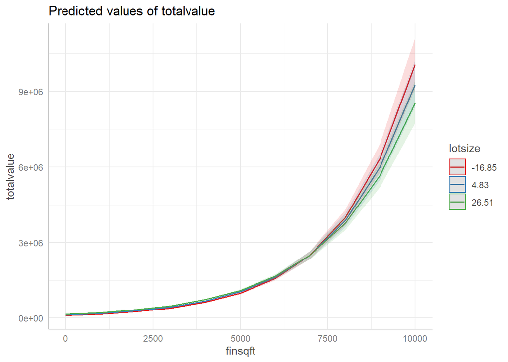

```r
plot(ggpredict(m6, terms = c("finsqft", "lotsize")))
```

We can set our own values for lotsize

```
## Model has log-transformed response. Back-transforming predictions to original response scale. Standard errors are still on the log-scale.
```

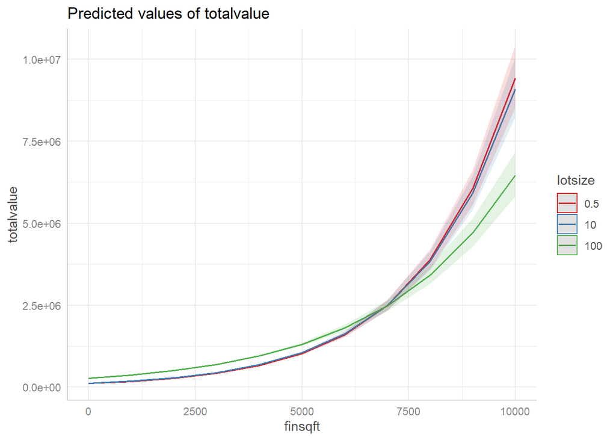

```r
plot(ggpredict(m6, terms = c("finsqft", "lotsize[0.5, 10, 100]")))
```

Format the labels to show dollar amounts

```
## Model has log-transformed response. Back-transforming predictions to original response scale. Standard errors are still on the log-scale.
```

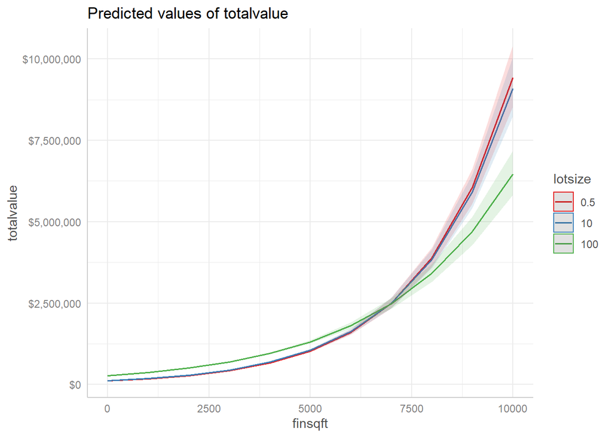

```r
plot(ggpredict(m6, terms = c("finsqft", "lotsize[0.5, 10, 100]")),
     labels = scales::dollar)
```

The effect of finsqft decreases as lotsize gets larger (around 100 acres). Also notice most of the plot is devoted to the handful of homes over 2.5 million dollars. If we like, we can zoom in on the plot and look at totalvalues from 0 to $1,000,000. We don’t see the interaction when zoomed in. The lines look roughly parallel.

```
## Model has log-transformed response. Back-transforming predictions to original response scale. Standard errors are still on the log-scale.
```

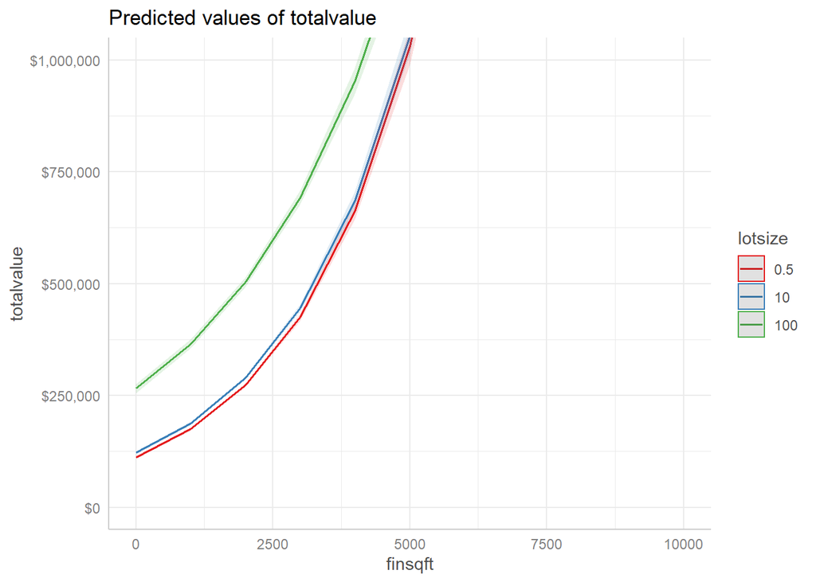

```r
plot(ggpredict(m6, terms = c("finsqft", "lotsize[0.5, 10, 100]")),
     labels = scales::dollar) +
  coord_cartesian(ylim = c(0, 1e6))
```

Switch the order of the terms to put lotsize on the x-axis

```
## Model has log-transformed response. Back-transforming predictions to original response scale. Standard errors are still on the log-scale.
```

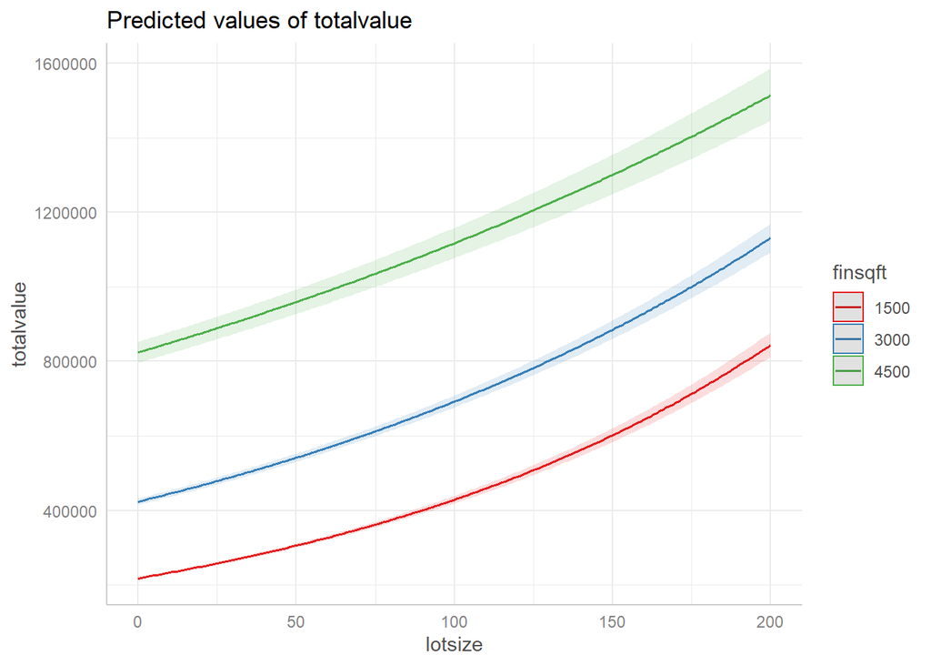

```r
plot(ggpredict(m6, terms = c("lotsize[0:200]", "finsqft[1500, 3000, 4500]")))
```

The effect of lotsize seems more pronounced for smaller homes.

Effect plots for censustract is more difficult because there are so many levels (20). Therefore we need to look at a few at a time.

```
## Model has log-transformed response. Back-transforming predictions to original response scale. Standard errors are still on the log-scale.
```

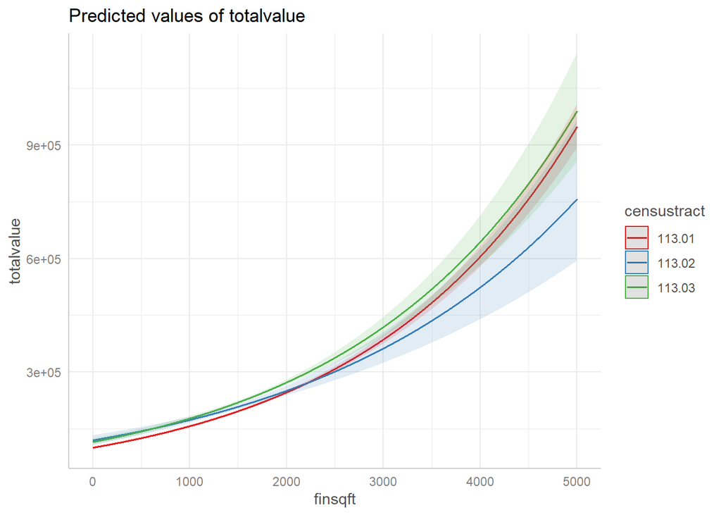

```r
plot(ggpredict(m6, terms = c("finsqft[0:5000]",
                             "censustract[113.01, 113.02, 113.03]")))
```

```
## Model has log-transformed response. Back-transforming predictions to original response scale. Standard errors are still on the log-scale.
```

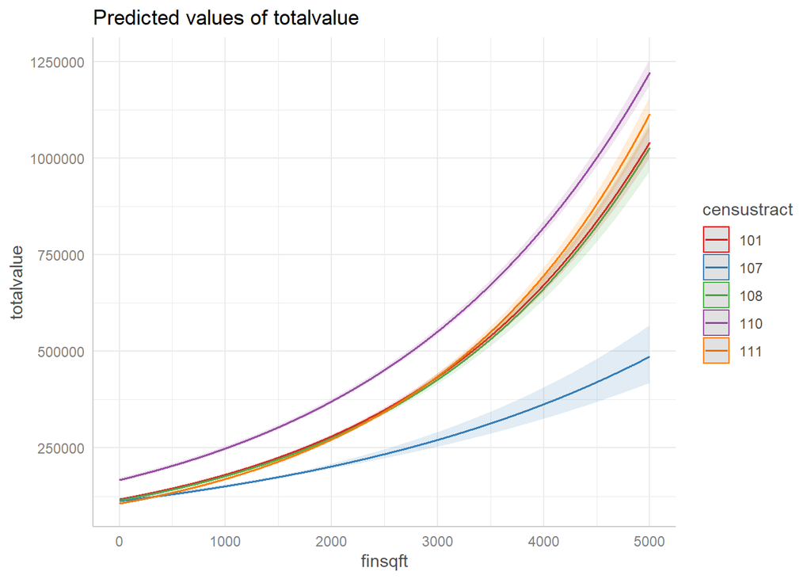

```r
plot(ggpredict(m6, terms = c("finsqft[0:5000]",
                             "censustract[101, 107, 108, 110, 111]")))
```

The ggpredict() result can be saved and used as a data frame with ggplot

```r
eff_out <- ggpredict(m6, terms = c("finsqft[0:5000]",
                        "censustract[101, 107, 108, 110, 111]"))
```

```
## Model has log-transformed response. Back-transforming predictions to original response scale. Standard errors are still on the log-scale.
```

```r
names(eff_out)
```

```
## [1] "x"         "predicted" "std.error" "conf.low"  "conf.high" "group"
```

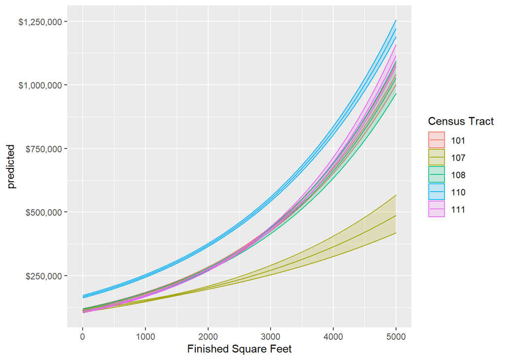

```r
eff_out <- eff_out %>%
  rename(`Census Tract` = group)
ggplot(eff_out, aes(x = x, y = predicted, color = `Census Tract`)) +
  geom_line() +
  geom_ribbon(aes(ymin = conf.low, ymax = conf.high, fill = `Census Tract`),
              alpha = 1/5) +
  scale_y_continuous(labels = scales::dollar) +
  labs(x = "Finished Square Feet")
```

When should you include interactions? What kind? How many? That requires some thought and expertise in the subject.

## YOUR TURN #4

- Add an interaction for cooling and finsqft to `m6` and save as `m7`.
- Is the interaction significant?
- Create an effect plot to visualize the interaction of cooling and finsqft (or lack thereof).

```r
# Add an interaction for cooling and finsqft to `m6` and save as `m7`.
m7 <- lm()

# Is the interaction significant?

# Create an effect plot to visualize the interaction of cooling and finsqft (or
# lack thereof).
```

## Non-linear effects [Video, Part 6]

Often the simple assumption of a linear effect of a predictor is unrealistic. Fortunately there are ways to fit non-linear effects in a linear model.

Let’s demostrate with some simulated data

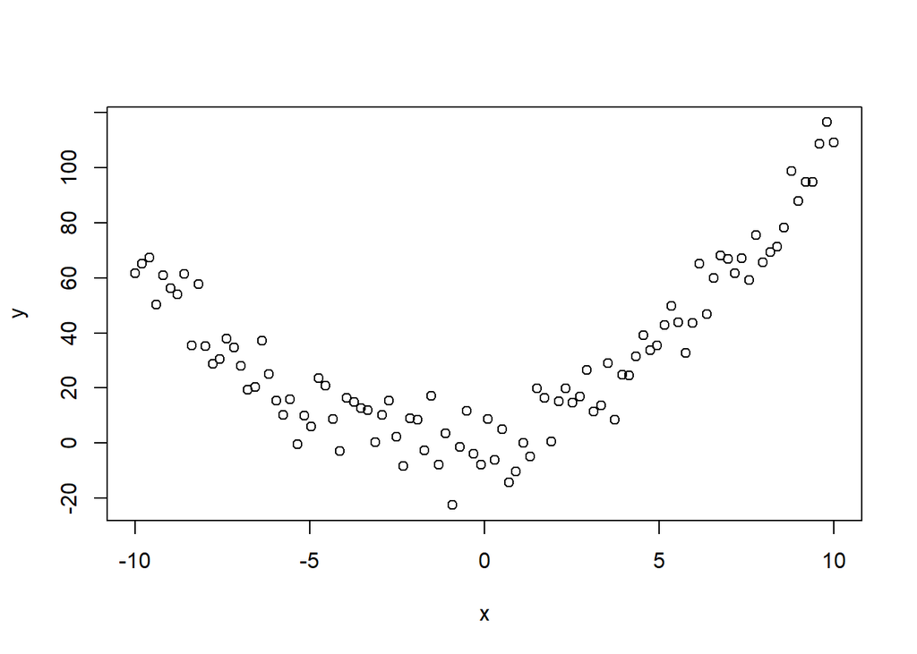

```r
# polynomial of degree 2
x <- seq(from = -10, to = 10, length.out = 100)
set.seed(3)
y <- 1.2 + 2*x + 0.9*x^2 + rnorm(100, sd = 10)
nl_dat <- data.frame(y, x)
plot(x, y)
```

Fit a polynomial model with the `poly()` function

```r
mod4 <- lm(y ~ poly(x, 2), data = nl_dat)
summary(mod4)
```

```
##
## Call:
## lm(formula = y ~ poly(x, 2), data = nl_dat)
##
## Residuals:
##      Min       1Q   Median       3Q      Max
## -23.3937  -6.1342   0.3919   7.0327  16.3910
##
## Coefficients:
##             Estimate Std. Error t value Pr(>|t|)
## (Intercept)  31.9164     0.8554   37.31   <2e-16 ***
## poly(x, 2)1 126.9080     8.5539   14.84   <2e-16 ***
## poly(x, 2)2 266.4715     8.5539   31.15   <2e-16 ***
## ---
## Signif. codes:  0 '***' 0.001 '**' 0.01 '*' 0.05 '.' 0.1 ' ' 1
##
## Residual standard error: 8.554 on 97 degrees of freedom
## Multiple R-squared:  0.9247, Adjusted R-squared:  0.9231
## F-statistic: 595.3 on 2 and 97 DF,  p-value: < 2.2e-16
```

Notice the coefficients are quite large. That’s because poly() generates *orthogonal* polynomials by default. That makes for numerical stability. Interpretation of coefficients isn’t really worth the effort.

We could fit the raw polynomials as follows and sort of “recover” the true values.

```r
mod5 <- lm(y ~ poly(x, 2, raw = TRUE), data = nl_dat)
summary(mod5)
```

```
##
## Call:
## lm(formula = y ~ poly(x, 2, raw = TRUE), data = nl_dat)
##
## Residuals:
##      Min       1Q   Median       3Q      Max
## -23.3937  -6.1342   0.3919   7.0327  16.3910
##
## Coefficients:
##                         Estimate Std. Error t value Pr(>|t|)
## (Intercept)              2.11953    1.28319   1.652    0.102
## poly(x, 2, raw = TRUE)1  2.17624    0.14668  14.836   <2e-16 ***
## poly(x, 2, raw = TRUE)2  0.87621    0.02813  31.152   <2e-16 ***
## ---
## Signif. codes:  0 '***' 0.001 '**' 0.01 '*' 0.05 '.' 0.1 ' ' 1
##
## Residual standard error: 8.554 on 97 degrees of freedom
## Multiple R-squared:  0.9247, Adjusted R-squared:  0.9231
## F-statistic: 595.3 on 2 and 97 DF,  p-value: < 2.2e-16
```

Use plot() and ggpredict() to plot fitted model with data

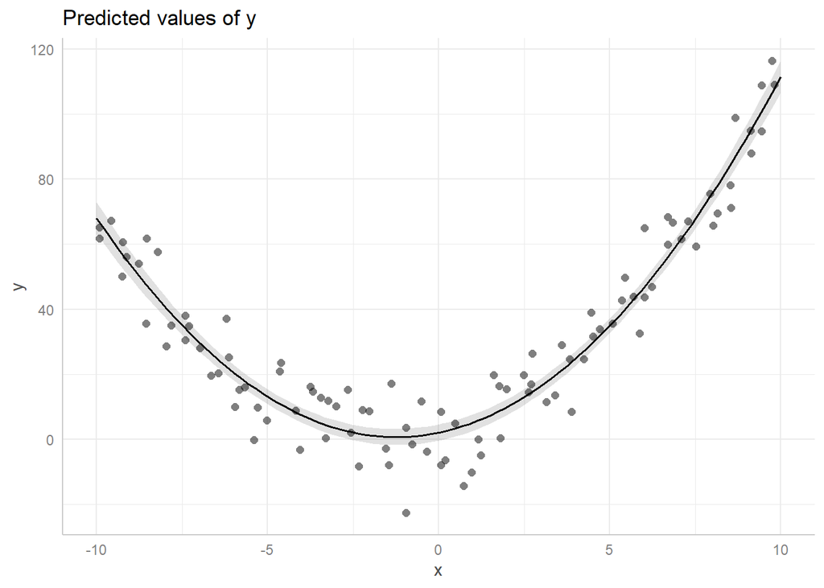

```r
plot(ggpredict(mod4), add.data = TRUE)
```

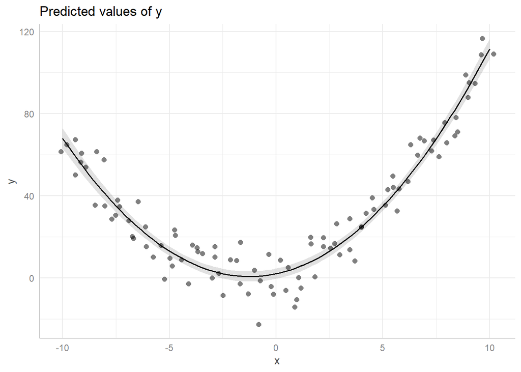

```r
plot(ggpredict(mod5), add.data = TRUE)
```

The modern approach to fitting non-linear effects is to use splines instead of polynomials.

Instead of `poly()` we can use the `ns()` function from the splines package. ns stands for natural splines. The second argument is the degrees of freedom. It may help to think of that as the number of times the smooth line changes directions.

```r
mod6 <- lm(y ~ ns(x, df = 2), data = nl_dat)
summary(mod6)
```

```
##
## Call:
## lm(formula = y ~ ns(x, df = 2), data = nl_dat)
##
## Residuals:
##      Min       1Q   Median       3Q      Max
## -21.0764  -6.7423   0.1437   7.4876  18.2382
##
## Coefficients:
##                Estimate Std. Error t value Pr(>|t|)
## (Intercept)      62.746      2.420   25.92   <2e-16 ***
## ns(x, df = 2)1  -77.728      5.433  -14.31   <2e-16 ***
## ns(x, df = 2)2   91.189      2.959   30.82   <2e-16 ***
## ---
## Signif. codes:  0 '***' 0.001 '**' 0.01 '*' 0.05 '.' 0.1 ' ' 1
##
## Residual standard error: 8.642 on 97 degrees of freedom
## Multiple R-squared:  0.9231, Adjusted R-squared:  0.9215
## F-statistic: 582.2 on 2 and 97 DF,  p-value: < 2.2e-16
```

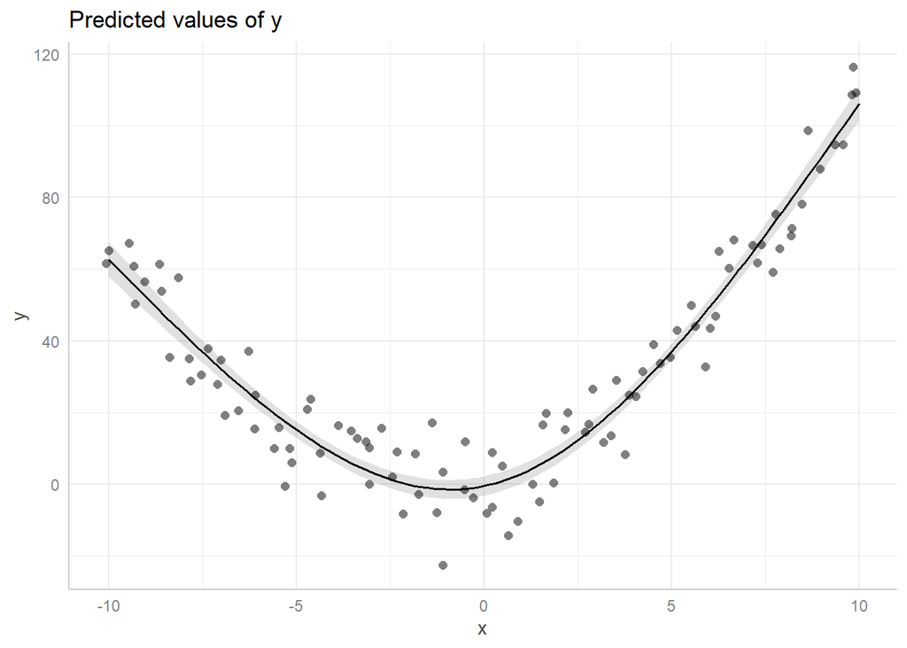

```r
plot(ggpredict(mod6), add.data = TRUE)
```

Natural splines essentially allow us to fit a series of cubic polynomials connected at knots located in the range of our data.

The ns() function transforms our data similar to a polynomial transformation.

```r
# simple example data
z <- 1:10

# classic polynomial transformation
p2_out <- poly(z, 2, raw = TRUE)
p2_out
```

```
##        1   2
##  [1,]  1   1
##  [2,]  2   4
##  [3,]  3   9
##  [4,]  4  16
##  [5,]  5  25
##  [6,]  6  36
##  [7,]  7  49
##  [8,]  8  64
##  [9,]  9  81
## [10,] 10 100
## attr(,"degree")
## [1] 1 2
## attr(,"class")
## [1] "poly"   "matrix"
```

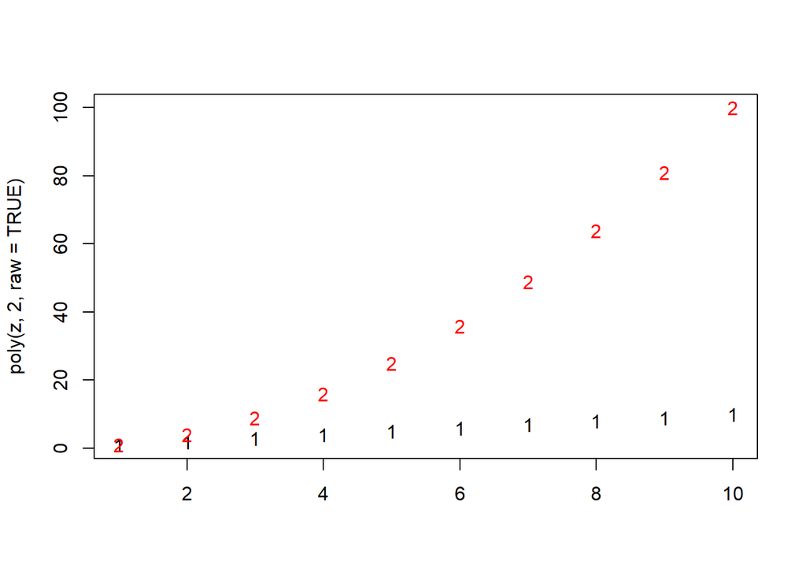

```r
matplot(poly(z, 2, raw = TRUE))
```

```r
cor(p2_out[,1], p2_out[,2])
```

```
## [1] 0.9745586
```

```r
# orthogonal, or uncorrelated, transformation
p2_out <- poly(z, 2)
p2_out
```

```
##                 1           2
##  [1,] -0.49543369  0.52223297
##  [2,] -0.38533732  0.17407766
##  [3,] -0.27524094 -0.08703883
##  [4,] -0.16514456 -0.26111648
##  [5,] -0.05504819 -0.34815531
##  [6,]  0.05504819 -0.34815531
##  [7,]  0.16514456 -0.26111648
##  [8,]  0.27524094 -0.08703883
##  [9,]  0.38533732  0.17407766
## [10,]  0.49543369  0.52223297
## attr(,"coefs")
## attr(,"coefs")$alpha
## [1] 5.5 5.5
##
## attr(,"coefs")$norm2
## [1]   1.0  10.0  82.5 528.0
##
## attr(,"degree")
## [1] 1 2
## attr(,"class")
## [1] "poly"   "matrix"
```

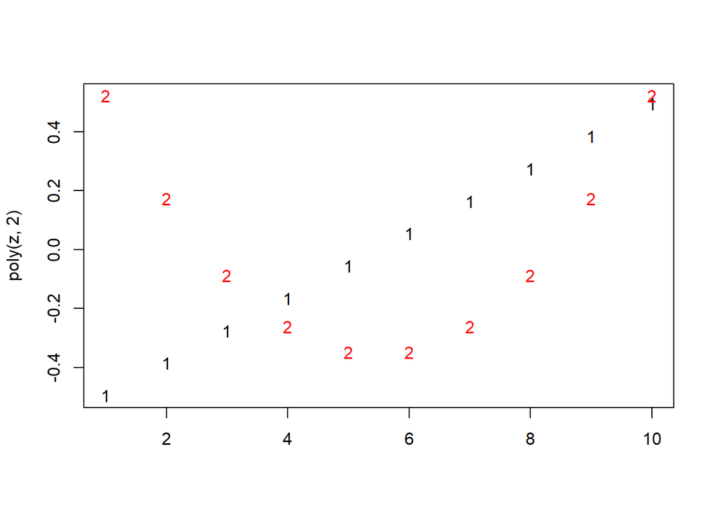

```r
matplot(poly(z, 2))
```

```r
cor(p2_out[,1], p2_out[,2])
```

```
## [1] -3.317659e-17
```

```r
# natural spline transformation
ns_out <- ns(z, 2)
ns_out
```

```
##               1           2
##  [1,] 0.0000000  0.00000000
##  [2,] 0.1674747 -0.10982084
##  [3,] 0.3219712 -0.20001558
##  [4,] 0.4505112 -0.25095810
##  [5,] 0.5401165 -0.24302231
##  [6,] 0.5783495 -0.15739986
##  [7,] 0.5652102  0.00590925
##  [8,] 0.5131362  0.22809668
##  [9,] 0.4351057  0.48953631
## [10,] 0.3440969  0.77060206
## attr(,"degree")
## [1] 3
## attr(,"knots")
## 50%
## 5.5
## attr(,"Boundary.knots")
## [1]  1 10
## attr(,"intercept")
## [1] FALSE
## attr(,"class")
## [1] "ns"     "basis"  "matrix"
```

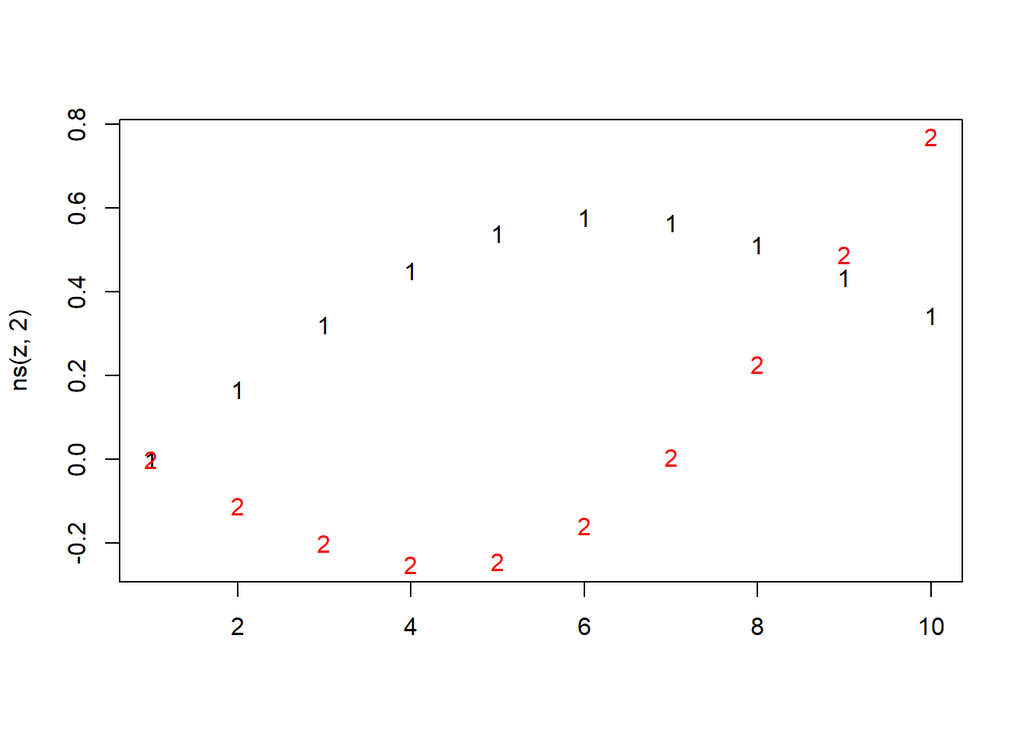

```r
matplot(ns(z, 2))
```

```r
cor(ns_out[,1], ns_out[,2])
```

```
## [1] -0.04882638
```

Frank Harrell states in his book *Regression Model Strategies* that 3 to 5 DF is almost always sufficient. His basic advice is to allocate more DF to variables you think are more important.

How can we assess whether we need a non-linear effect? Partial residual plots can help. Also called term plots and component-residual plots. We’ll use the `crPlots()` function from the car package.

Partial-residual plots show the relationship between a predictor and the response variable given that the other predictors are also in the model.

Let’s fit a model with no interactions. `crPlot()` does not work for models with interactions.

```r
m8 <- lm(log(totalvalue) ~ finsqft + lotsize + censustract + cooling,
         data = homes)
```

Notice we specify the numeric variables just as we would in a model.

The blue dashed line is the fitted slope.  
The purple line is a smooth trend line.

A curving purple line indicates a non-linear effect may be justified.

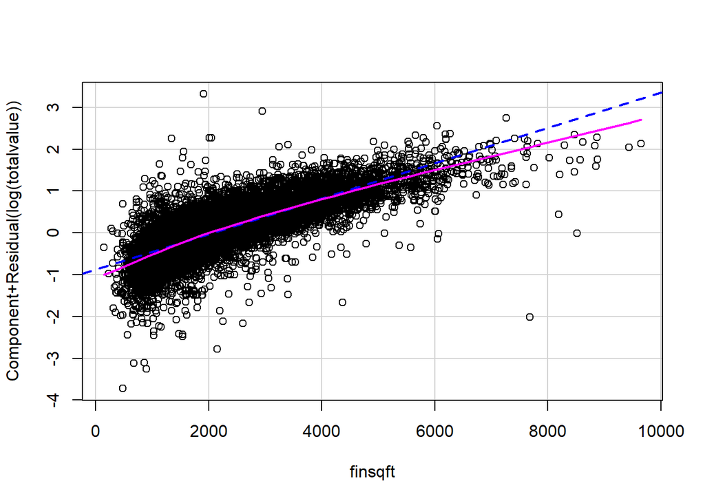

```r
crPlots(m8, terms = ~ finsqft)
```

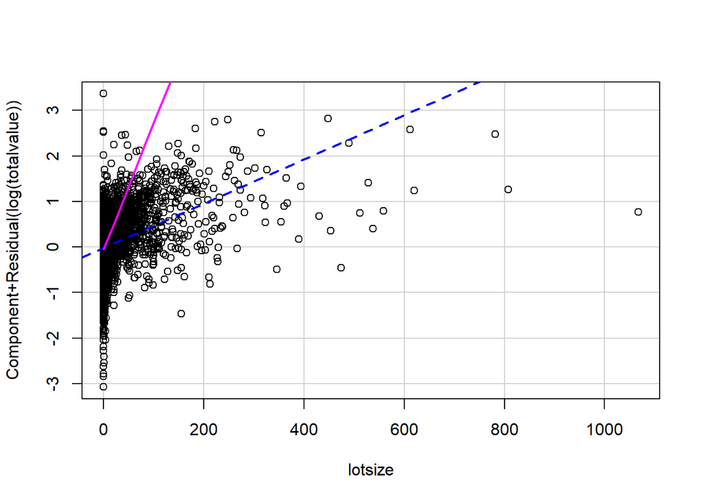

```r
crPlots(m8, terms = ~ lotsize)
```

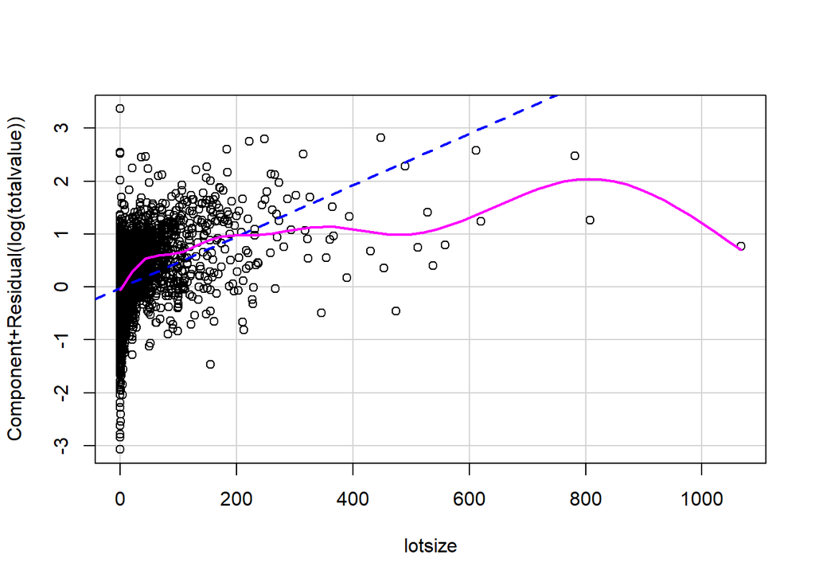

```r
# use a different smoother for the smooth trend line
crPlots(m8, terms = ~ lotsize, smooth=list(smoother=gamLine))
```

It appears both finsqft and lotsize may be affecting totalvalue in a non-linear fashion. Let’s fit a non-linear effect for finsqft using a natural spline with 3 DF.

```r
m9 <- lm(log(totalvalue) ~ ns(finsqft, df = 3) + lotsize + censustract + cooling,
         data = homes)
summary(m9)
```

```
##
## Call:
## lm(formula = log(totalvalue) ~ ns(finsqft, df = 3) + lotsize +
##     censustract + cooling, data = homes)
##
## Residuals:
##     Min      1Q  Median      3Q     Max
## -3.9955 -0.1430 -0.0029  0.1473  3.2812
##
## Coefficients:
##                        Estimate Std. Error t value Pr(>|t|)
## (Intercept)           1.141e+01  1.697e-02 672.141  < 2e-16 ***
## ns(finsqft, df = 3)1  1.989e+00  1.248e-02 159.405  < 2e-16 ***
## ns(finsqft, df = 3)2  3.660e+00  4.318e-02  84.764  < 2e-16 ***
## ns(finsqft, df = 3)3  2.908e+00  4.584e-02  63.447  < 2e-16 ***
## lotsize               5.082e-03  7.916e-05  64.193  < 2e-16 ***
## censustract102.01    -1.308e-01  9.499e-03 -13.768  < 2e-16 ***
## censustract102.02     6.066e-02  1.080e-02   5.617 1.96e-08 ***
## censustract103       -7.335e-02  8.904e-03  -8.237  < 2e-16 ***
## censustract104.01    -1.280e-01  1.001e-02 -12.788  < 2e-16 ***
## censustract104.02    -2.734e-02  1.035e-02  -2.640  0.00828 **
## censustract105       -1.710e-02  1.032e-02  -1.657  0.09762 .
## censustract106.01    -2.368e-02  1.046e-02  -2.265  0.02350 *
## censustract106.02    -5.663e-02  1.027e-02  -5.512 3.57e-08 ***
## censustract107       -2.408e-01  1.095e-02 -21.991  < 2e-16 ***
## censustract108       -3.465e-02  1.123e-02  -3.084  0.00204 **
## censustract109.02     1.588e-01  3.844e-02   4.130 3.63e-05 ***
## censustract110        2.463e-01  9.113e-03  27.028  < 2e-16 ***
## censustract111       -5.451e-02  8.491e-03  -6.420 1.39e-10 ***
## censustract112.01    -7.046e-02  1.025e-02  -6.871 6.51e-12 ***
## censustract112.02    -2.694e-02  1.019e-02  -2.644  0.00821 **
## censustract113.01    -1.341e-01  9.702e-03 -13.825  < 2e-16 ***
## censustract113.02    -7.052e-02  1.811e-02  -3.894 9.89e-05 ***
## censustract113.03    -5.021e-02  1.134e-02  -4.429 9.51e-06 ***
## censustract114       -4.503e-01  1.003e-02 -44.904  < 2e-16 ***
## coolingCentral Air    2.238e-01  5.837e-03  38.338  < 2e-16 ***
## ---
## Signif. codes:  0 '***' 0.001 '**' 0.01 '*' 0.05 '.' 0.1 ' ' 1
##
## Residual standard error: 0.2853 on 30233 degrees of freedom
## Multiple R-squared:  0.7688, Adjusted R-squared:  0.7686
## F-statistic:  4189 on 24 and 30233 DF,  p-value: < 2.2e-16
```

The coefficients are impossible to interpret. Effect plots are our only hope.

```
## Model has log-transformed response. Back-transforming predictions to original response scale. Standard errors are still on the log-scale.
```

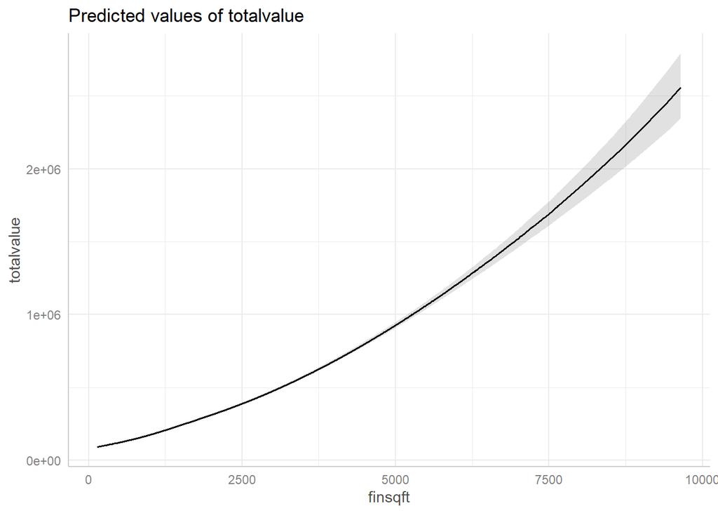

```r
plot(ggpredict(m9, terms = "finsqft"))
```

The partial-residual plot looks better

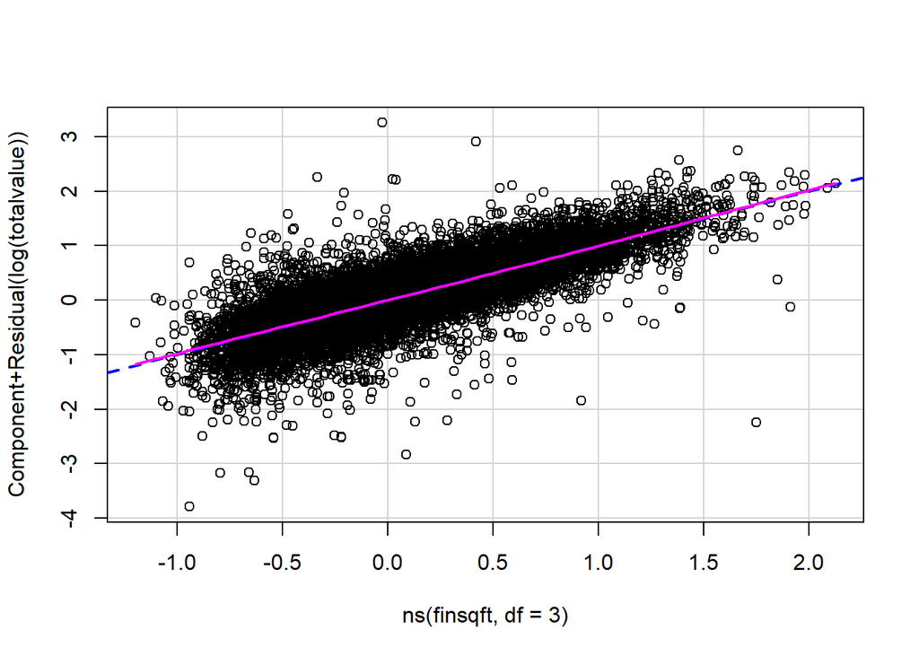

```r
crPlots(m9, ~ns(finsqft, df = 3))
```

## YOUR TURN #5

- Update model `m9` to include a non-linear effect for lotsize using a natural spline with 5 DF and save the new model as `m10`.
- Generate an effect plot for the non-linear lotsize effect.
- Check the partial-residual plot for lotsize in model `m10`.

```r
# Update model `m9` to include a non-linear effect for lotsize using a natural
# spline with 5 DF and save the new model as `m10`.
m10 <- lm()

# Generate an effect plot for the non-linear lotsize effect.


# Check the partial-residual plot for lotsize in model `m10`.
```

## Comparing models [Video, Part 7]

### Partial F test

How do we determine if one model is better than another?

One way is through hypothesis testing with the partial F test.

NULL: two models are equally “good”  
ALTERNATIVE: the more complex model is better

Note: the smaller model must be a subset of the larger model!

We can run this test with the base R `anova()` function.

Example:

```r
# The model from the previous exercise:
m10 <- lm(log(totalvalue) ~ ns(finsqft, df = 3) + ns(lotsize, df = 5) +
            censustract + cooling,
          data = homes)

# a more complex model with an interactionvbetween ns(finsqft, df = 3) and
# ns(lotsize, df = 5)
m11 <- lm(log(totalvalue) ~ ns(finsqft, df = 3) + ns(lotsize, df = 5) +
            censustract + cooling +
            ns(finsqft, df = 3):ns(lotsize, df = 5),
          data = homes)
```

Test that both models are equally good at modeling totalvalue. Notice that `m10` is a subset of `m11`

```r
anova(m10, m11)
```

```
## Analysis of Variance Table
##
## Model 1: log(totalvalue) ~ ns(finsqft, df = 3) + ns(lotsize, df = 5) +
##     censustract + cooling
## Model 2: log(totalvalue) ~ ns(finsqft, df = 3) + ns(lotsize, df = 5) +
##     censustract + cooling + ns(finsqft, df = 3):ns(lotsize, df = 5)
##   Res.Df    RSS Df Sum of Sq      F    Pr(>F)
## 1  30229 2286.6
## 2  30214 2215.5 15    71.039 64.587 < 2.2e-16 ***
## ---
## Signif. codes:  0 '***' 0.001 '**' 0.01 '*' 0.05 '.' 0.1 ' ' 1
```

It appears `m11` is superior to `m10` The low p-value says we reject the null; the bigger model appears to be better than the smaller model.

### AIC and BIC

We can also use the AIC or BIC information criteria. These are not hypothesis tests. We simply see which has a lower value. These values estimate the out-of-sample accuracy if we were to use these models to make predictions on new data. Simply use the `AIC` and/or `BIC` functions with the model objects. The main difference between the two is that BIC imposes a heavier penalty for models with more predictors.

```r
AIC(m10, m11)
```

```
##     df      AIC
## m10 30 7780.731
## m11 45 6855.754
```

```r
BIC(m10, m11)
```

```
##     df      BIC
## m10 30 8030.257
## m11 45 7230.042
```

The nice thing about AIC/BIC is that we don’t need to worry about whether the models contain a subset of predictors. They just need to have the same response variable.

While lower is better, sometimes it’s hard to know how much lower AIC/BIC needs to be. If a really complex model is only slightly lower than an easier to understand smaller model, the smaller model may be preferable.

## YOUR TURN #6

- Fit the following three models, each with increasing levels of complexity in the splines.
- Compare the models using `anova`, `AIC` and `BIC`. Which is better?

```r
# Fit the following three models, each with increasing levels of complexity in
# the splines.
mod_a <- lm(log(totalvalue) ~ ns(finsqft, df = 3) * ns(lotsize, df = 3) +
            censustract + cooling,
          data = homes)
mod_b <- lm(log(totalvalue) ~ ns(finsqft, df = 4) * ns(lotsize, df = 4) +
            censustract + cooling,
          data = homes)
mod_c <- lm(log(totalvalue) ~ ns(finsqft, df = 5) * ns(lotsize, df = 5) +
            censustract + cooling,
          data = homes)

# Compare the models using `anova`, `AIC` and `BIC`. Which is better?
```

## Using a linear model [Video, Part 8]

Once we have a linear model we may want to use it to make predictions for new data. We can do that with the `predict()` function. Note the new data needs to be in a data frame.

Let’s say we want to use this model:

```r
m12 <- lm(log(totalvalue) ~ ns(finsqft, df = 5) * ns(lotsize, df = 5) +
            censustract * ns(finsqft, df = 5) + cooling,
          data = homes)
summary(m12)
```

```
##
## Call:
## lm(formula = log(totalvalue) ~ ns(finsqft, df = 5) * ns(lotsize,
##     df = 5) + censustract * ns(finsqft, df = 5) + cooling, data = homes)
##
## Residuals:
##     Min      1Q  Median      3Q     Max
## -2.9684 -0.1316  0.0012  0.1377  3.3834
##
## Coefficients:
##                                             Estimate Std. Error t value
## (Intercept)                                11.399136   0.152451  74.772
## ns(finsqft, df = 5)1                        0.870256   0.141428   6.153
## ns(finsqft, df = 5)2                        1.231419   0.162838   7.562
## ns(finsqft, df = 5)3                        1.892883   0.178687  10.593
## ns(finsqft, df = 5)4                        3.959110   0.731198   5.415
## ns(finsqft, df = 5)5                        4.704075   1.331463   3.533
## ns(lotsize, df = 5)1                       -1.588311   0.171270  -9.274
## ns(lotsize, df = 5)2                       -0.123545   0.131748  -0.938
## ns(lotsize, df = 5)3                        3.622165   0.801614   4.519
## ns(lotsize, df = 5)4                        7.487665   2.991355   2.503
## ns(lotsize, df = 5)5                       14.388095   6.533757   2.202
## censustract102.01                           1.233490   0.206541   5.972
## censustract102.02                           1.058578   0.232722   4.549
## censustract103                              0.090532   0.203144   0.446
## censustract104.01                           0.112442   0.126228   0.891
## censustract104.02                           0.027893   0.226213   0.123
## censustract105                              0.530627   0.226084   2.347
## censustract106.01                          -0.302680   0.335961  -0.901
## censustract106.02                           1.938215   0.225934   8.579
## censustract107                              1.388717   0.277131   5.011
## censustract108                              1.512674   0.282092   5.362
## censustract109.02                         -65.652267 130.495842  -0.503
## censustract110                              0.879675   0.173304   5.076
## censustract111                              0.636620   0.146789   4.337
## censustract112.01                           0.032162   0.120537   0.267
## censustract112.02                           0.012006   0.159288   0.075
## censustract113.01                          -0.004298   0.134484  -0.032
## censustract113.02                           2.543222   0.325047   7.824
## censustract113.03                           1.557342   0.317731   4.901
```

[output cut: 265 more lines]

```
## ns(finsqft, df = 5)2:censustract113.03    2.55e-06 ***
## ns(finsqft, df = 5)3:censustract113.03    0.000844 ***
## ns(finsqft, df = 5)4:censustract113.03    0.010877 *
## ns(finsqft, df = 5)5:censustract113.03    0.175957
## ns(finsqft, df = 5)1:censustract114       0.617019
## ns(finsqft, df = 5)2:censustract114       0.491312
## ns(finsqft, df = 5)3:censustract114       0.001181 **
## ns(finsqft, df = 5)4:censustract114       0.901446
## ns(finsqft, df = 5)5:censustract114       0.369102
## ---
## Signif. codes:  0 '***' 0.001 '**' 0.01 '*' 0.05 '.' 0.1 ' ' 1
##
## Residual standard error: 0.2647 on 30107 degrees of freedom
## Multiple R-squared:  0.8018, Adjusted R-squared:  0.8008
## F-statistic: 811.9 on 150 and 30107 DF,  p-value: < 2.2e-16
```

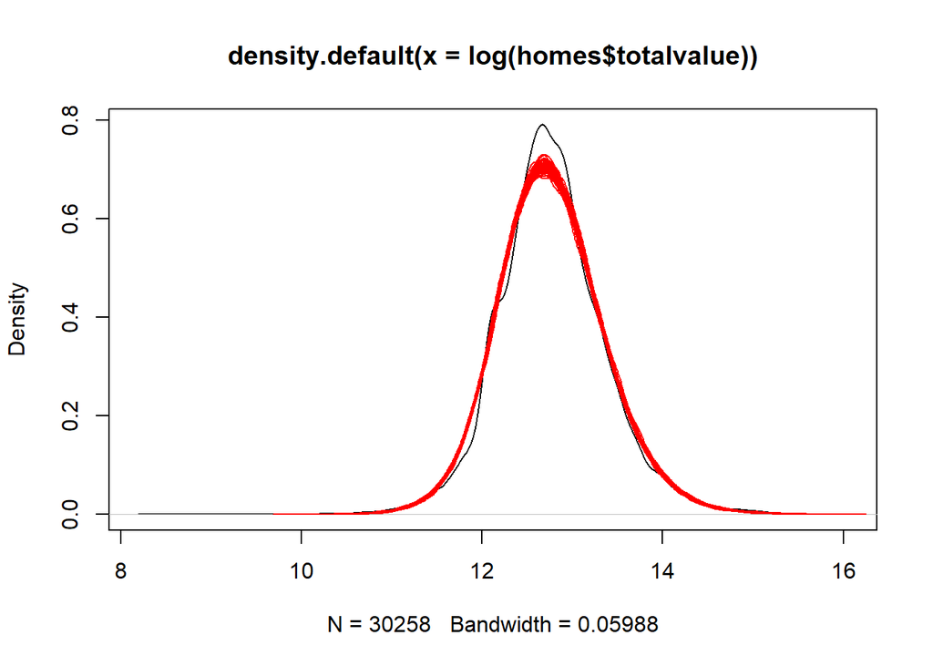

```r
sim_tv <- simulate(m12, nsim = 50)
plot(density(log(homes$totalvalue)))
for(i in 1:50)lines(density(sim_tv[[i]]), col = "red")
```

What is the expected mean totalvalue of a home with the following characteristics:

- finsqft = 2500
- lotsize = 1
- cooling = “Central Air”
- censustract = “101”

To answer this, first we need to enter this information into a data frame:

```r
newdata <- data.frame(finsqft = 2500,
                      lotsize = 1,
                      cooling = "Central Air",
                      censustract = "101")
```

Next we use the `predict` function with our `newdata` data frame:

```r
predict(m12, newdata = newdata) %>% exp()
```

```
##        1
## 432957.1
```

with 95% confidence interval

```r
predict(m12, newdata = newdata, interval = "confidence") %>% exp()
```

```
##        fit      lwr      upr
## 1 432957.1 419529.2 446814.8
```

To predict a SINGLE home price, we need to set `interval = "prediction"`. Notice the predicted value is the same but the interval is much wider since we’re more uncertain about the expected value of a particular house:

```r
predict(m12, newdata = newdata, interval = "prediction") %>% exp()
```

```
##        fit      lwr      upr
## 1 432957.1 257446.2 728120.3
```

```r
newdata <- data.frame(finsqft = 2500,
                      lotsize = 1:10,
                      cooling = "Central Air",
                      censustract = "101")
head(newdata)
```

```
##   finsqft lotsize     cooling censustract
## 1    2500       1 Central Air         101
## 2    2500       2 Central Air         101
## 3    2500       3 Central Air         101
## 4    2500       4 Central Air         101
## 5    2500       5 Central Air         101
## 6    2500       6 Central Air         101
```

```r
predict(m12, newdata = newdata, interval = "confidence") %>% exp()
```

```
##         fit      lwr      upr
## 1  432957.1 419529.2 446814.8
## 2  452393.5 441256.0 463812.1
## 3  462996.6 451627.3 474652.1
## 4  468040.7 456591.0 479777.5
## 5  472796.1 461287.4 484591.9
## 6  477579.0 466003.6 489441.9
## 7  482389.3 470739.3 494327.7
## 8  487226.9 475494.1 499249.1
## 9  492091.5 480267.7 504206.4
## 10 496983.2 485060.0 509199.5
```

This is basically how effect plots are created.

```r
pred_out <- predict(m12, newdata = newdata, interval = "confidence") %>%
  exp() %>%
  as.data.frame() %>%
  mutate(lotsize = 1:10)
```

Now create the effect plot “by hand” with ggplot:

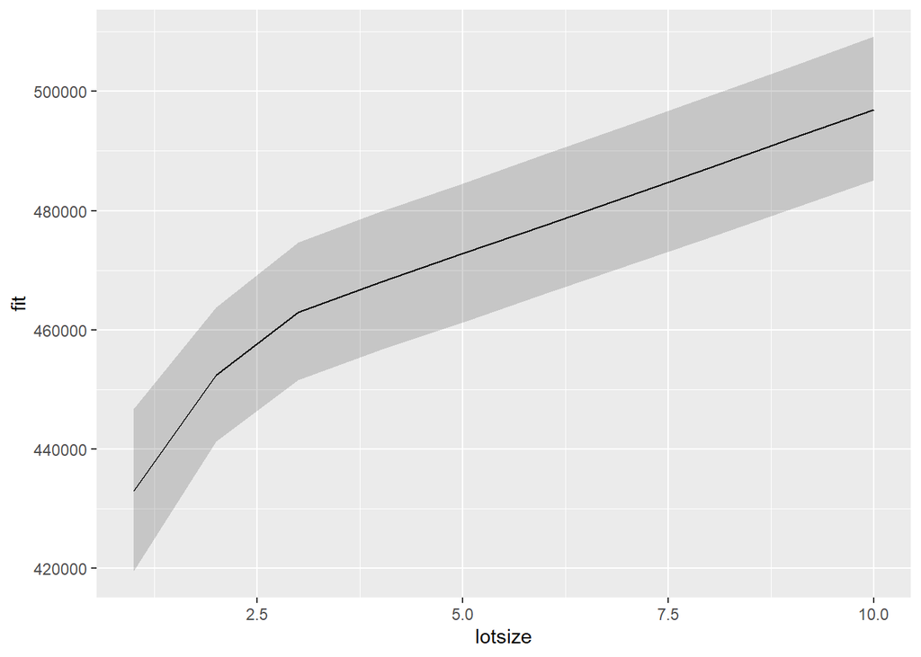

```r
ggplot(pred_out, aes(x = lotsize, y = fit)) +
  geom_line() +
  geom_ribbon(mapping = aes(ymin = lwr, ymax = upr), alpha = 1/5)
```

Here’s the same plot with ggpredict; use `condition` argument to set other predictors to specific values.

```r
eff_out <- ggpredict(m12, terms = "lotsize[1:10]",
                    condition = c(finsqft = 2500,
                                  cooling = "Central Air",
                                  censustract = "101"))
```

```
## Model has log-transformed response. Back-transforming predictions to original response scale. Standard errors are still on the log-scale.
```

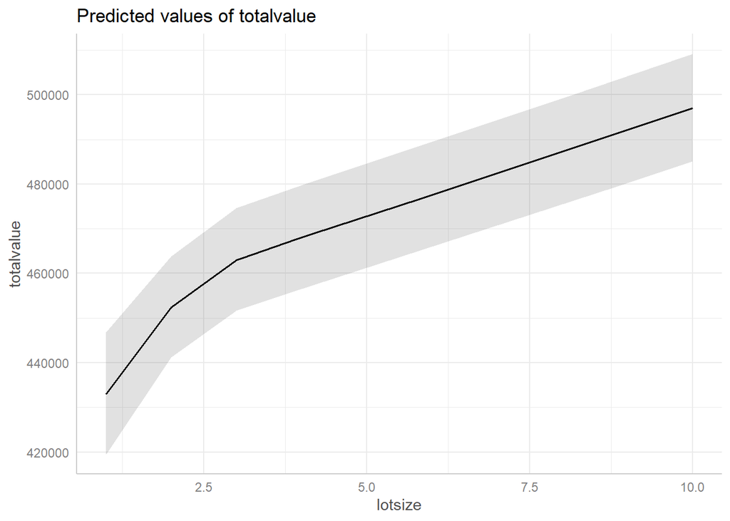

```r
plot(eff_out)
```

## YOUR TURN #7

Modify the code below to produce an effect plot for finsqft (with values set to 1500, 2000, 2500, 3000) and lotsize set to 0.5 acre. Leave cooling and censustract as is.

```r
eff_out <- ggpredict(m12, terms = "lotsize[1:10]",
                    condition = c(finsqft = 2500,
                                  cooling = "Central Air",
                                  censustract = "101"))
plot(eff_out)
```

## Communicating modeling results

The stargazer package can produce regression tables for articles and presentations. It can output tables in html, text or LaTeX. Below we demonstrate with text.

The basic usage is as follows

```r
stargazer(m2, m3, type = "text", title = "Modeling Results")
```

```
##
## Modeling Results
## ===============================================================================
##                                         Dependent variable:
##                     -----------------------------------------------------------
##                                           log(totalvalue)
##                                  (1)                           (2)
## -------------------------------------------------------------------------------
## finsqft                       0.001***                      0.0005***
##                               (0.00000)                     (0.00000)
##
## lotsize                                                     0.004***
##                                                             (0.0001)
##
## Constant                      11.721***                     11.724***
##                                (0.005)                       (0.005)
##
## -------------------------------------------------------------------------------
## Observations                   30,258                        30,258
## R2                              0.661                         0.678
## Adjusted R2                     0.661                         0.678
## Residual Std. Error      0.345 (df = 30256)            0.337 (df = 30255)
## F Statistic         59,080.390*** (df = 1; 30256) 31,811.080*** (df = 2; 30255)
## ===============================================================================
## Note:                                               *p<0.1; **p<0.05; ***p<0.01
```

Since our dependent variable has been log transformed, we may want to exponentiate the coefficients. We can do that with the `apply.coef = exp` argument.

```r
stargazer(m2, m3, type = "text", title = "Modeling Results",
          apply.coef = exp)
```

```
##
## Modeling Results
## ===============================================================================
##                                         Dependent variable:
##                     -----------------------------------------------------------
##                                           log(totalvalue)
##                                  (1)                           (2)
## -------------------------------------------------------------------------------
## finsqft                       1.001***                      1.000***
##                               (0.00000)                     (0.00000)
##
## lotsize                                                     1.004***
##                                                             (0.0001)
##
## Constant                   123,168.200***                123,494.200***
##                                (0.005)                       (0.005)
##
## -------------------------------------------------------------------------------
## Observations                   30,258                        30,258
## R2                              0.661                         0.678
## Adjusted R2                     0.661                         0.678
## Residual Std. Error      0.345 (df = 30256)            0.337 (df = 30255)
## F Statistic         59,080.390*** (df = 1; 30256) 31,811.080*** (df = 2; 30255)
## ===============================================================================
## Note:                                               *p<0.1; **p<0.05; ***p<0.01
```

The style argument allows you to create tables according to styles preferred by various journals. See `?stargazer`

“ajps” = American Journal of Political Science

```r
stargazer(m2, m3,
          type = "text",
          title = "Modeling Results",
          apply.coef = exp,
          style = "ajps")
```

```
##
## Modeling Results
## -----------------------------------------------------------------------------
##                                          log(totalvalue)
##                               Model 1                      Model 2
## -----------------------------------------------------------------------------
## finsqft                       1.001***                     1.000***
##                              (0.00000)                    (0.00000)
## lotsize                                                    1.004***
##                                                            (0.0001)
## Constant                   123168.200***                123494.200***
##                               (0.005)                      (0.005)
## N                              30258                        30258
## R-squared                      0.661                        0.678
## Adj. R-squared                 0.661                        0.678
## Residual Std. Error      0.345 (df = 30256)           0.337 (df = 30255)
## F Statistic         59080.390*** (df = 1; 30256) 31811.080*** (df = 2; 30255)
## -----------------------------------------------------------------------------
## ***p < .01; **p < .05; *p < .1
```

# “asr” American Sociological Review

```r
stargazer(m2, m3,
          type = "text",
          title = "Modeling Results",
          apply.coef = exp,
          style = "asr")
```

```
##
## Modeling Results
## -------------------------------------------------------------------------------
##                                           log(totalvalue)
##                                  (1)                           (2)
## -------------------------------------------------------------------------------
## finsqft                       1.001***                      1.000***
## lotsize                                                     1.004***
## Constant                   123,168.200***                123,494.200***
## N                              30,258                        30,258
## R2                              0.661                         0.678
## Adjusted R2                     0.661                         0.678
## Residual Std. Error      0.345 (df = 30256)            0.337 (df = 30255)
## F Statistic         59,080.390*** (df = 1; 30256) 31,811.080*** (df = 2; 30255)
## -------------------------------------------------------------------------------
## *p < .05; **p < .01; ***p < .001
```

We can set the variable names with the `covariate.labels` argument.

```r
stargazer(m2, m3,
          type = "text",
          title = "Modeling Results",
          style = "ajps",
          apply.coef = exp,
          covariate.labels = c("Finished Sq Ft",
                               "Lot Size",
                               "Intercept"))
```

```
##
## Modeling Results
## -----------------------------------------------------------------------------
##                                          log(totalvalue)
##                               Model 1                      Model 2
## -----------------------------------------------------------------------------
## Finished Sq Ft                1.001***                     1.000***
##                              (0.00000)                    (0.00000)
## Lot Size                                                   1.004***
##                                                            (0.0001)
## Intercept                  123168.200***                123494.200***
##                               (0.005)                      (0.005)
## N                              30258                        30258
## R-squared                      0.661                        0.678
## Adj. R-squared                 0.661                        0.678
## Residual Std. Error      0.345 (df = 30256)           0.337 (df = 30255)
## F Statistic         59080.390*** (df = 1; 30256) 31811.080*** (df = 2; 30255)
## -----------------------------------------------------------------------------
## ***p < .01; **p < .05; *p < .1
```

We can omit certain model statistics. Below we omit the F statistic. Notice we also we set the name of the dependent variable to display as “Total Value”

```r
stargazer(m2, m3,
          type = "text",
          title = "Modeling Results",
          style = "ajps",
          covariate.labels = c("Finished Sq Ft",
                               "Lot Size",
                               "Intercept"),
          omit.stat = "f",
          apply.coef = exp,
          dep.var.labels = "Total Value")
```

```
##
## Modeling Results
## ---------------------------------------------------------
##                                  Total Value
##                          Model 1            Model 2
## ---------------------------------------------------------
## Finished Sq Ft           1.001***           1.000***
##                         (0.00000)          (0.00000)
## Lot Size                                    1.004***
##                                             (0.0001)
## Intercept             123168.200***      123494.200***
##                          (0.005)            (0.005)
## N                         30258              30258
## R-squared                 0.661              0.678
## Adj. R-squared            0.661              0.678
## Residual Std. Error 0.345 (df = 30256) 0.337 (df = 30255)
## ---------------------------------------------------------
## ***p < .01; **p < .05; *p < .1
```

Again, see `?stargazer` for many more options.

## References

- Faraway, J. (2005). *Linear Models in R*. London: Chapman & Hall.
- Fox, J. (2002). *A R and S-Plus Companion to Applied Regression*. London: Sage.
- Harrell, F. (2015). *Regression Modeling Strategies* (2nd ed.). New York: Springer.
- Kutner, M., et al. (2005). *Applied Linear Statistical Models* (5th ed.). New York: McGraw-Hill.
- Maindonald J., Braun, J.W. (2010). *Data Analysis and Graphics Using R* (3rd ed.). Cambridge: Cambridge Univ Press.